# Homework 7

By 19086

2019-11-28

## Question 1 (8.3)

The Count $5$ test for equal variances in Section 6.4 is based on the maximum number of extreme points. Example 6.15 shows that the Count $5$ criterion is not applicable for unequal sample sizes. Implement a permutation test for equal variance based on the maximum number of extreme points that applies when sample sizes are not necessarily equal.

## Answer 1

```
## ASL:  0.3026973
```

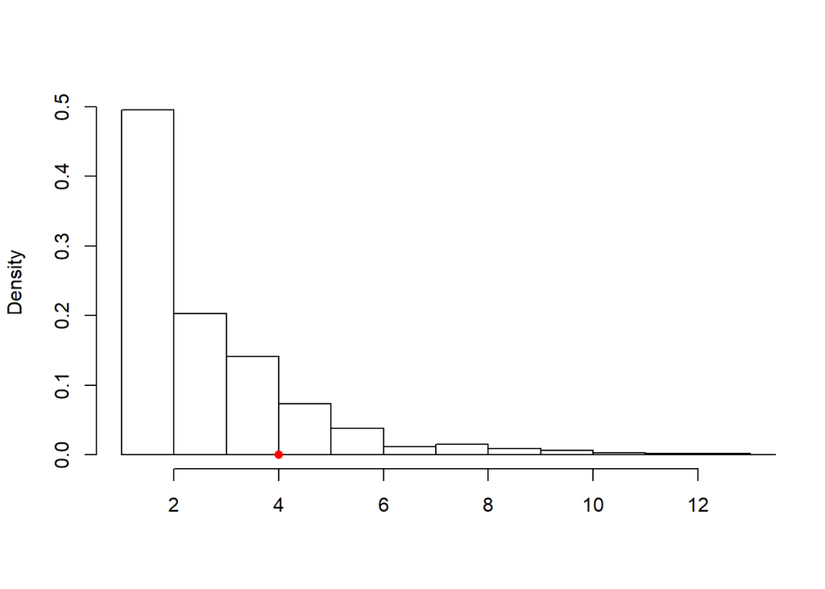

```r
set.seed(12345)

# data preparation, setting 1
n1 <- 20; n2 <- 30; n <- n1 + n2          # n1 neq n2
mu1 <- mu2 <- 0                           # same mu and sigma
sigma1 <- sigma2 <- 1
x <- rnorm(n1, mu1, sigma1)
y <- rnorm(n2, mu2, sigma2)

count5.statistic <- function(x, y) {
  # return statistic, the number of outs
  X <- x - mean(x)    # centered by sample mean
  Y <- y - mean(y)
  outx <- sum(X > max(Y)) + sum(X < min(Y))
  outy <- sum(Y > max(X)) + sum(Y < min(X))
  return(max(c(outx, outy)))
}

count5.test.permutation <- function(x, y){
  z <- c(x, y)
  reps1 <- count5.statistic(x, y)           # statistics using all samples
  R <- 1000; reps <- numeric(R)             # permutation to get statistics
  for (i in 1:R) {
    k <- sample(1:n, size = n1, replace = FALSE)
    x1 <- z[k]; y1 <- z[-k] # complement of x1
    reps[i] <- count5.statistic(x1, y1)
  }
  reps2 <- mean(abs(c(reps1, reps)) >= abs(reps1)) # Get achieved significance level (ASL)

  # print the result
  cat("ASL: ", reps2)

  # draw histogram
  hist(reps, main = "", freq = FALSE, xlab = "", xlim=c(1,13))
  points(reps1, 0, cex = 1, pch = 16, col=2, lwd=8)
  return(reps2)                             # ASL
}

# implement
asl <- count5.test.permutation(x, y)
```

Let’s try a example that $x$ and $y$ have different variances.

```r
# data preparation, setting 1
n1 <- 30; n2 <- 40; n <- n1 + n2          # n1 neq n2
mu1 <- 1; mu2 <- 0                        # mu
sigma1 <- 1; sigma2 <- 2                  # different sig
x <- rnorm(n1, mu1, sigma1)
y <- rnorm(n2, mu2, sigma2)

# implement
asl <- count5.test.permutation(x, y)
```

```
## ASL:  0.02597403
```

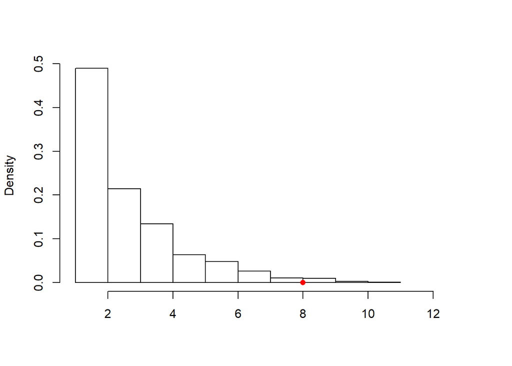

## Question 2 (Permutation Slide P.31.)

Power comparison (distance correlation test versus ball covariance test)

- Model 1: $Y = X/4 + e$
- Model 2: $Y = X/4 \times e$
- $X \sim N(0_2, I_2)$, $e \sim N(0_2, I_2)$, $X$ and $e$ are independent.

## Answer 2

The following code is basic test functions to be used later. Those codes are copy from permutation slides.

```r
library(Ball); library(MASS); library(boot); library(snowfall)
set.seed(12345)

# permutation test for distance correlation
dCov <- function(x, y) {
  x <- as.matrix(x); y <- as.matrix(y)
  n <- nrow(x); m <- nrow(y)
  if (n != m || n < 2)
    stop("Sample sizes must agree")
  if (! (all(is.finite(c(x, y)))))
    stop("Data contains missing or infinite values")

  Akl <- function(x) {
    d <- as.matrix(dist(x))
    m <- rowMeans(d); M <- mean(d)
    a <- sweep(d, 1, m); b <- sweep(a, 2, m)
    b + M
  }

  A <- Akl(x); B <- Akl(y)
  sqrt(mean(A * B))
}

ndCov2 <- function(z, ix, dims) {
  # dims contains dimensions of x and y
  p <- dims[1]
  q <- dims[2]
  d <- p + q
  x <- z[ , 1:p]     # leave x as is
  y <- z[ix, -(1:p)] # permute rows of y
  return(nrow(z) * dCov(x, y)^2)
}
```

Now, let’s focus on model 1, test the difference of distributions of $X$ and $Y$.

```r
# model 1
myfun <- function(ii){
  mu <- c(0, 0)
  set.seed(ii)
  Sigma <- diag(c(1,1))
  X <- MASS::mvrnorm(n=n, mu=mu, Sigma=Sigma)
  e <- MASS::mvrnorm(n=n, mu=mu, Sigma=Sigma)
  Y = X/4 + e
  z <- cbind(X, Y)

  boot.obj <- boot::boot(data=z, statistic=ndCov2, R=50, sim="permutation", dims=c(2, 2))
  tb <- c(boot.obj$t0, boot.obj$t)
  p.cor <- mean(tb >= tb[1])
  p.ball <- bcov.test(z[,1:2], z[,3:4])$p.value
  return(as.numeric(c(p.cor, p.ball)))
}

length.out <- 50; from <- 15; to <- 100
pow.cor <- numeric(length.out); pow.ball <- numeric(length.out)
m <- 50

ii <- 1
snowfall::sfInit(parallel =TRUE, cpus=10)
```

```
## R Version:  R version 3.6.1 (2019-07-05)
```

```r
snowfall::sfExport("dCov", "ndCov2")
snowfall::sfLibrary(Ball)
```

```
## Library Ball loaded.
```

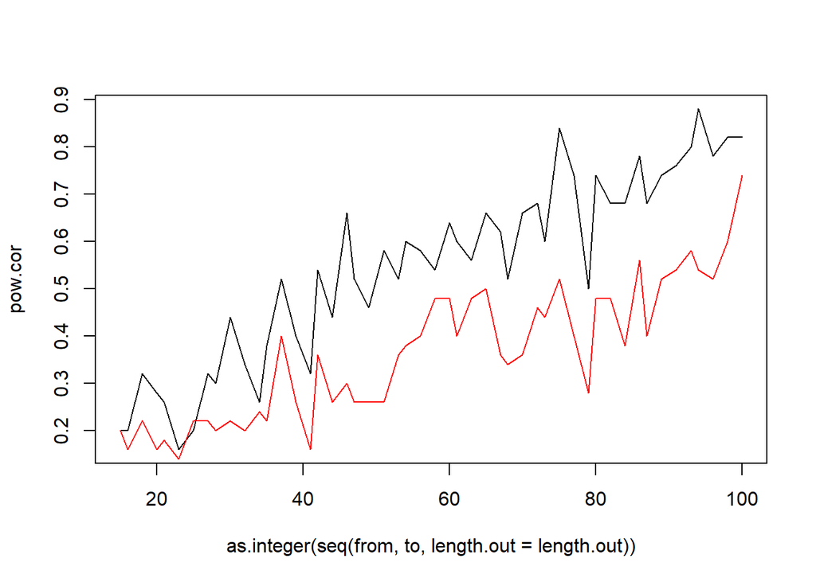

```r
for(n in as.integer(seq(from, to, length.out=length.out))){
  snowfall::sfExport("n", "m")
  res <- unlist(snowfall::sfLapply(x=1:m, fun=myfun))    # repeat m times
  p.cor <- res[2*(1:m)-1]
  p.ball <- res[2*(1:m)]
  alpha <- 0.1
  pow.cor[ii] <- mean(p.cor < alpha)
  pow.ball[ii] <- mean(p.ball < alpha)
  ii <- ii + 1
}
snowfall::sfStop()

plot(x=as.integer(seq(from, to, length.out=length.out)), y=pow.cor, "l", lty=1, col=1)
lines(x=as.integer(seq(from, to, length.out=length.out)), y=pow.ball, col=2)
```

Black line is the power of distance correlation test by number of samples, red line is the of ball covariance test.

The following is model 2.

```r
myfun <- function(ii){
  mu <- c(0, 0)
  Sigma <- diag(c(1,1))
  set.seed(ii)
  X <- MASS::mvrnorm(n=n, mu=mu, Sigma=Sigma)
  e <- MASS::mvrnorm(n=n, mu=mu, Sigma=Sigma)
  Y = X/4 * e
  z <- cbind(X, Y)

  boot.obj <- boot::boot(data=z, statistic=ndCov2, R=10, sim="permutation", dims=c(2, 2))
  tb <- c(boot.obj$t0, boot.obj$t)
  p.cor <- mean(tb >= tb[1])
  p.ball <- bcov.test(z[,1:2], z[,3:4], R=10)$p.value
  return(as.numeric(c(p.cor, p.ball)))
}

length.out <- 50; from <- 15; to <- 100
pow.cor <- numeric(length.out); pow.ball <- numeric(length.out)
m <- 10

ii <- 1
snowfall::sfInit(parallel =TRUE, cpus=10)
snowfall::sfExport("dCov", "ndCov2")
snowfall::sfLibrary(Ball)
```

```
## Library Ball loaded.
```

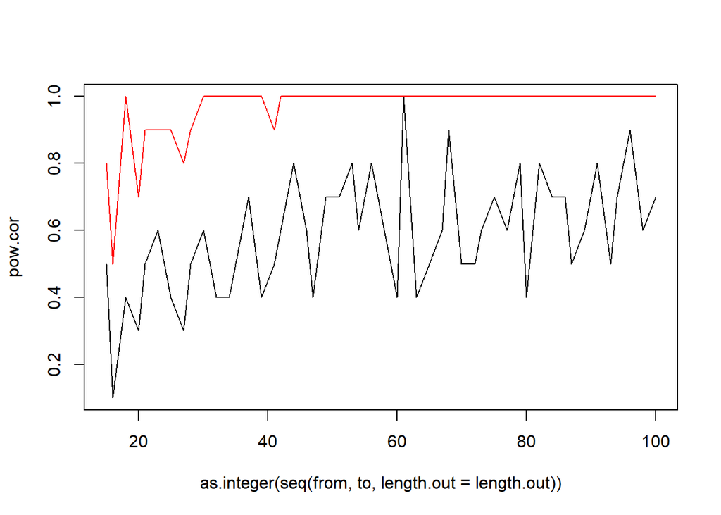

```r
for(n in as.integer(seq(from, to, length.out=length.out))){
  snowfall::sfExport("n", "m")
  res <- unlist(snowfall::sfLapply(x=1:m, fun=myfun))

  p.cor <- res[2*(1:m)-1]
  p.ball <- res[2*(1:m)]
  alpha <- 0.1
  pow.cor[ii] <- mean(p.cor < alpha)
  pow.ball[ii] <- mean(p.ball < alpha)
  ii <- ii + 1
}
snowfall::sfStop()
plot(x=as.integer(seq(from, to, length.out=length.out)), y=pow.cor, "l", lty=1, col=1)
lines(x=as.integer(seq(from, to, length.out=length.out)), y=pow.ball, col=2)
```

We can compare the power of distance correlation test versus ball covariance test clearly. Their power are both good, but distance correlation test performs better when location of samples are different, while ball covariance test perform better when their scale are different.